# R Notebook

# Figure 6C

Plot the heatmap of the correlation between Flow (protien) and scRNAseq (RNA)

```r
# need to melt the matrix
library(reshape2)
library(ggplot2)

longData<- melt(df.cor)

head(longData)
```

|  | Var1 | Var2 | value |
| --- | --- | --- | --- |
| 1 | Astrocytes | Astrocytes | 0.5553328 |
| 2 | RadialGlia | Astrocytes | 0.1305815 |
| 3 | Neurons1 | Astrocytes | -0.4098105 |
| 4 | Neurons2 | Astrocytes | -0.4858683 |
| 5 | Astrocytes | RadialGlia | 0.1522878 |
| 6 | RadialGlia | RadialGlia | 0.4451073 |

```r
colnames(longData) <- c("FC","scRNA","R2")

ggplot(longData, aes(x=scRNA,y=FC, fill =R2)) + geom_tile() +
  scale_fill_gradient2(low = "#075AFF",
                       mid = "#FFFFCC",
                       high = "#FF0000") +
   guides(fill = guide_colourbar(label = TRUE,
                                ticks = FALSE)) + theme_bw() +
  coord_fixed()  +scale_x_discrete(expand=c(0,0))+
  scale_y_discrete(expand=c(0,0))+ theme(text = element_text(size=16, colour = "black"),
        axis.text.x = element_text(size = 18, colour = "black", angle = 90), axis.text.y = element_text(size= 18, colour = "black"))  + xlab('scRNAseq') + ylab('Flow Cytometry')

output_path <- "/Users/rhalenathomas/Documents/Projects_Papers/PhenoID/ForFigures/scRNA/"

pdf(paste(output_path,"FC_scRNA_correlation.pdf"), width = 8, height = 5)
```

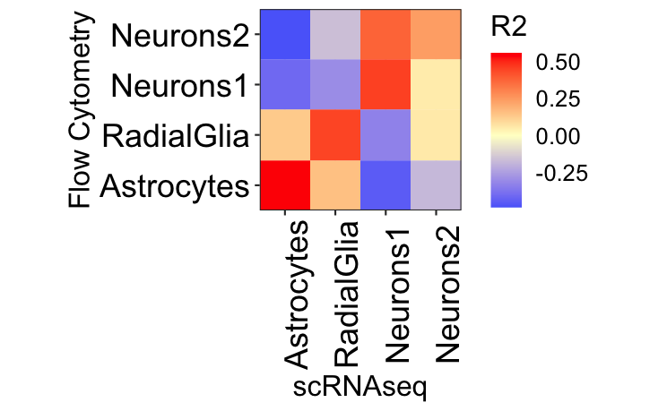

```r
ggplot(longData, aes(x=scRNA,y=FC, fill =R2)) + geom_tile() +
  scale_fill_gradient2(low = "#075AFF",
                       mid = "#FFFFCC",
                       high = "#FF0000", midpoint = 0, limit = c(-0.5,0.5)) +
   guides(fill = guide_colourbar(label = TRUE,
                                ticks = FALSE)) + theme_bw() +
  coord_fixed()  +scale_x_discrete(expand=c(0,0)) +
  scale_y_discrete(expand=c(0,0)) +
  theme(text = element_text(size=16, colour = "black"),
        axis.text.x = element_text(size = 16, colour = "black", angle = 90), axis.text.y = element_text(size= 16, colour = "black"))  + xlab('scRNAseq') + ylab('Flow Cytometry')

dev.off()
```

# Figure 6D

UMAP of the different FACS sorted populations in the merged data object.

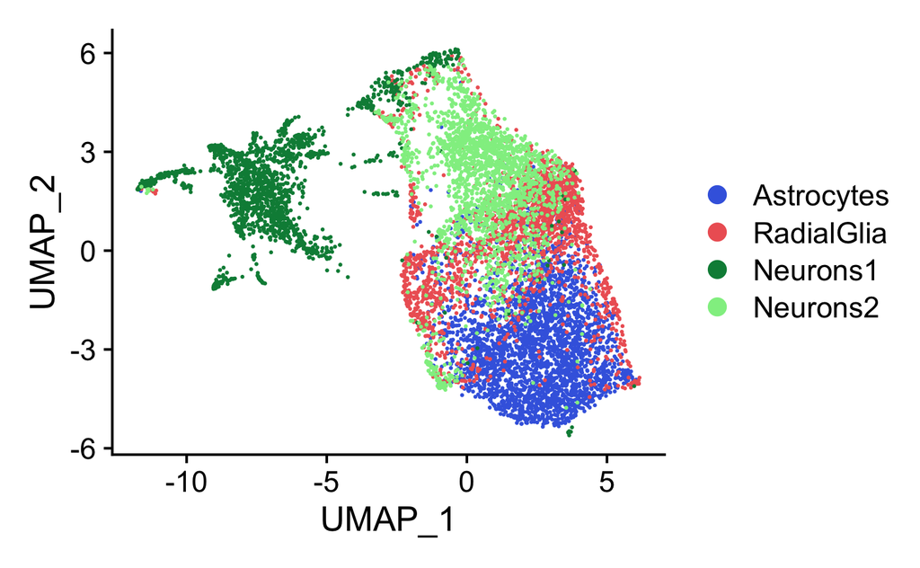

# Figure 6E

Proportions of main cell types in each sorted population

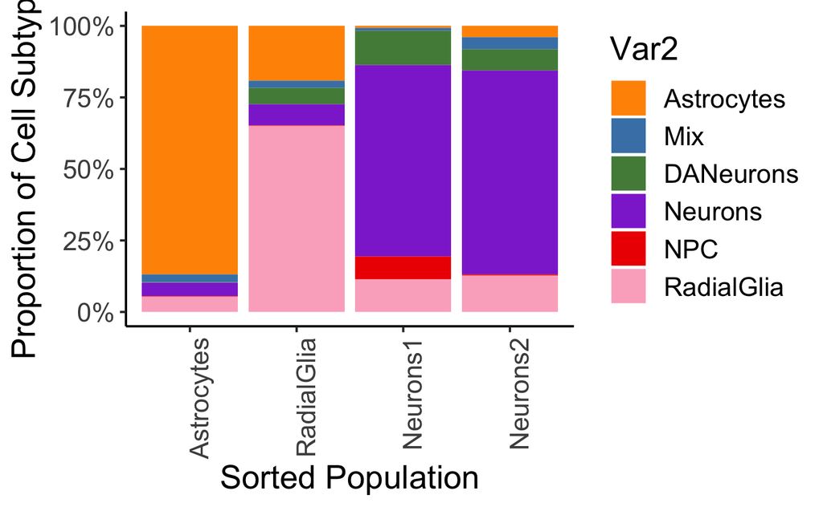

# Figure 6F

UMAP coloured by subtypes of cells

[figure not shown]

```r
# choose the order for cell types to appear in the legend
# by default this will go by cluster size
sample.order <- c("Astrocytes-immature","Astrocytes-reactive", "Astrocytes-resting",
                  "DANeurons-SN","DANeurons-VM","DANeurons-VTA",
                  "Mix",
                  "Neurons-Endocrine","Neurons-Excitatory","Neurons-GABAergic",
                  "Neurons-Glutamatergic","Neurons-Mature","Neurons_stem_potential",
                  "Neurons-5HT","NPC",
                  "RadialGlia-VZ", "RadialGlia-SVZ","RadialGlia-outer",
                  "RadialGlia-NSC", "RadiaGlia-proliferating")
sample.order <- rev(sample.order)


clust.colours <- c("#F1C166","#FF9400","#E95901",          # oranges Astrocytes
                   "#02E8BA","#528A47","#0AE90C",     # greens DA neurons
                   "steelblue",   # mix
                   "#E3C3FC", "#B166F6","#917EA5",
                   "#6B03F6", "#9770CB","#C9B5EF",   # neurons 2  CP, GRIA2
                   "#8E36D2", "red2", # NPC
                   "#C092A1","#F5C3FC","#F74D84"
                   ,"#FCB1C6","#FA7A92"
                   )

#DimPlot(seu.sc, pt.size = 0.1, order = sample.order, label = TRUE, group.by = 'Cell_Subtype_Markers')
Idents(seu.sc) <- 'Subtypes'

DimPlot(seu.sc, order = sample.order, cols = clust.colours, shuffle = TRUE, raster=FALSE, pt.size = 0.25, label = TRUE, repel = TRUE)
```

```r
DimPlot(seu.sc, order = sample.order, cols = clust.colours, shuffle = TRUE, raster=FALSE, pt.size = 0.25, label = FALSE)



pdf(paste(output_path,"UMAP_CellSubtypes.pdf"),width = 10, height = 5)
```

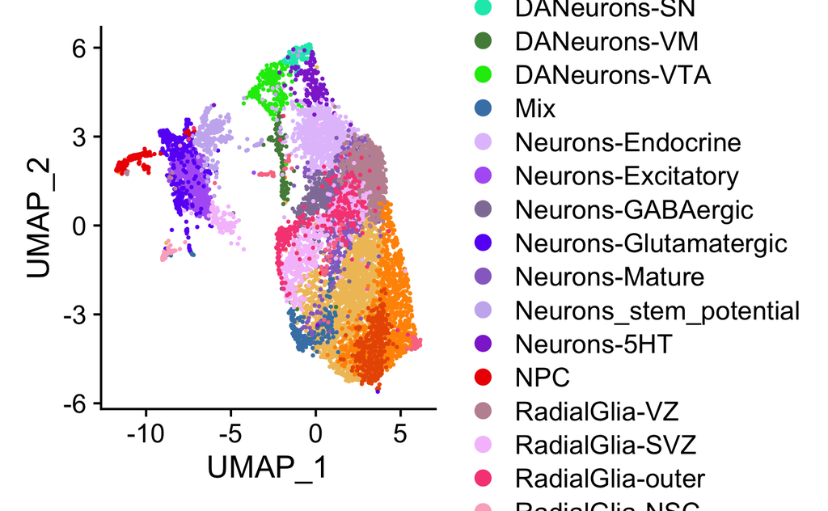

```r
DimPlot(seu.sc, order = sample.order, cols = clust.colours, shuffle = TRUE, raster=FALSE, pt.size = 0.25, label = FALSE)
dev.off()
```

```r
# Figures S25
# Make the split dim plots with the same colours
Idents(seu.sc) <- 'Subtypes'

DimPlot(seu.sc, order = sample.order, cols = clust.colours, shuffle = TRUE, raster=FALSE, split.by = "orig.ident",pt.size = 0.25, label = FALSE, ncol = 2)


pdf(paste(output_path,"UMAP_CellSubtypesSplit.pdf"),width = 10, height = 5)
```

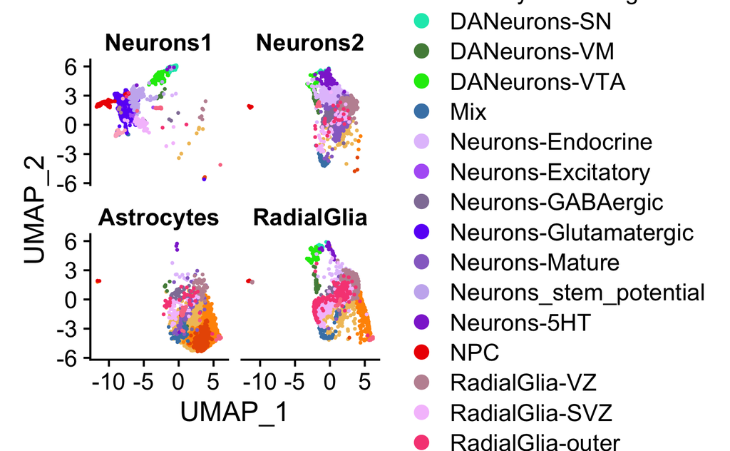

```r
DimPlot(seu.sc, order = sample.order, cols = clust.colours, shuffle = TRUE, raster=FALSE, split.by = "orig.ident",pt.size = 0.25, label = FALSE, ncol = 2)
dev.off()
```

# Figure 6G

Proportions of DA subtypes in neurons1 and neurons2

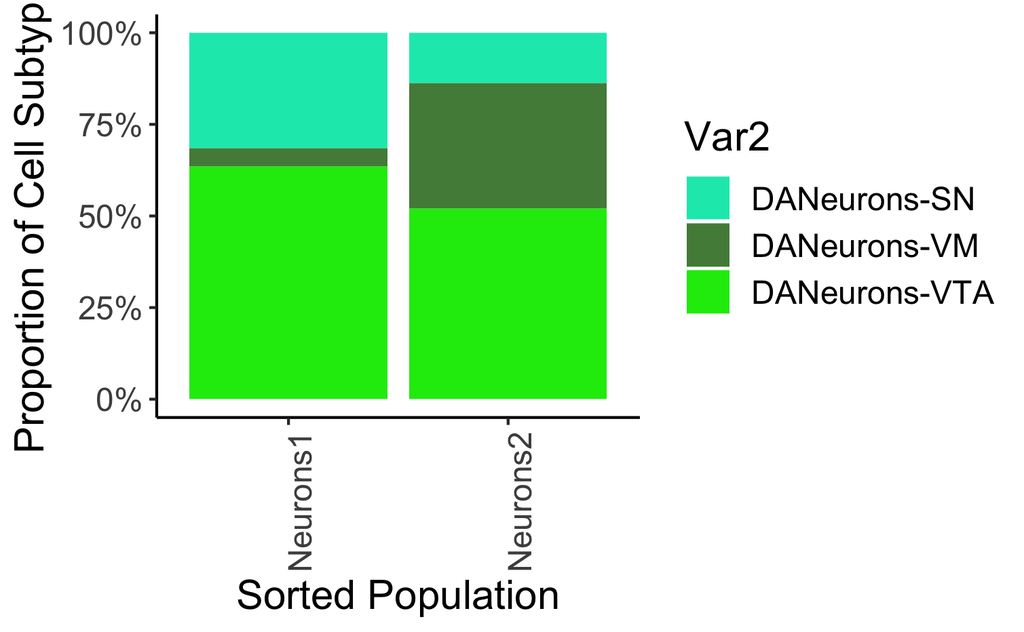

```r
# get count of cell subtypes for each sorted population
# get all neuron subtypes
sample.lables <- as.data.frame(table(seu.sc$orig.ident, seu.sc$Subtypes))

sample.lables$Freq <- as.double(sample.lables$Freq)

sample.table <- sample.lables %>% filter(Var1 %in% c("Neurons1","Neurons2"))


sample.table.da <- sample.table %>% filter(Var2 %in% c("DANeurons-SN","DANeurons-VM","DANeurons-VTA"))


pop.order <- c("Neurons1","Neurons2")

# for DA neurons in the two neurons pops
sample.order <- c("DANeurons-SN","DANeurons-VM","DANeurons-VTA")
df <- sample.table.da %>% mutate(Var2 = factor(Var2, levels = sample.order))
df <- df %>% mutate(Var1 = factor(Var1, levels = pop.order))
clust.colours<- c("#02E8BA","#528A47","#0AE90C")


ggplot(df, aes(x = Var1,y=Freq ,fill = Var2)) + geom_bar(position= "fill", stat = "identity")  +
  RotatedAxis() +
  scale_y_continuous(labels = scales::percent_format()) + theme_classic() + theme(text = element_text(size=15),
        axis.text.x = element_text(angle=90, hjust=1))  + xlab('Sorted Population') + ylab('Proportion of Cell Subtype')  + scale_fill_manual(values = clust.colours)
```

```r
NA
NA
NA
NA
NA
NA
```

Figure S25 counts of subtypes for each main cell type, grouped by the four sorted populations.

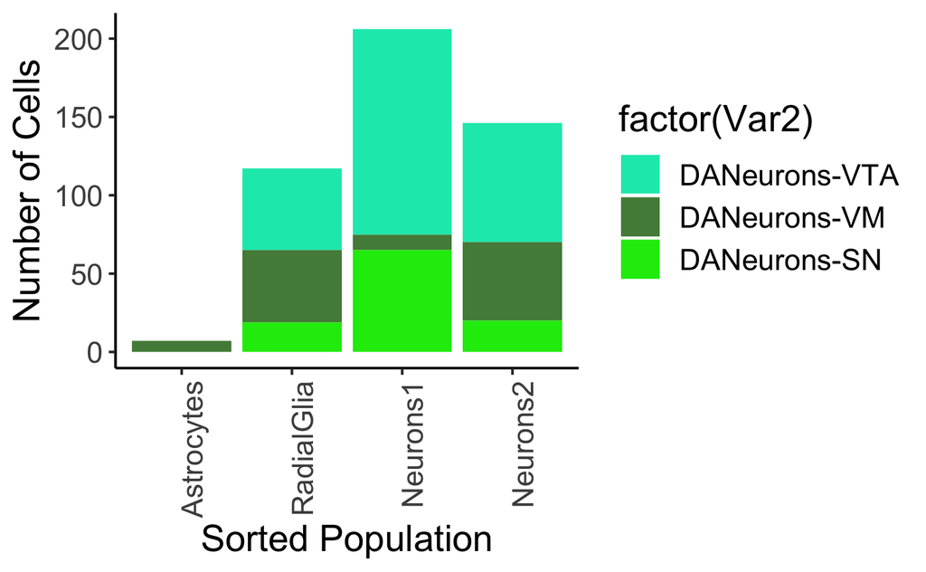

Counts for astrocytes

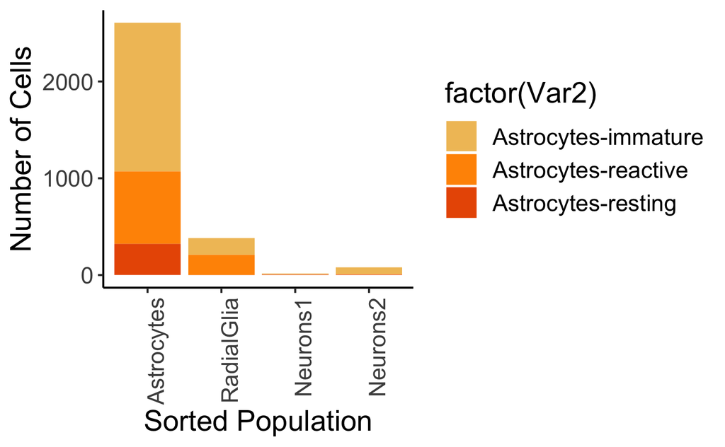

Counts for Neurons

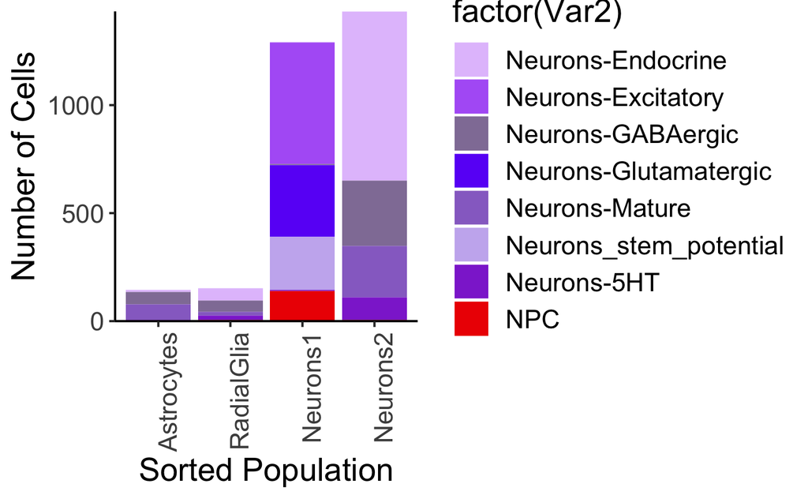

Counts for Radial Glia

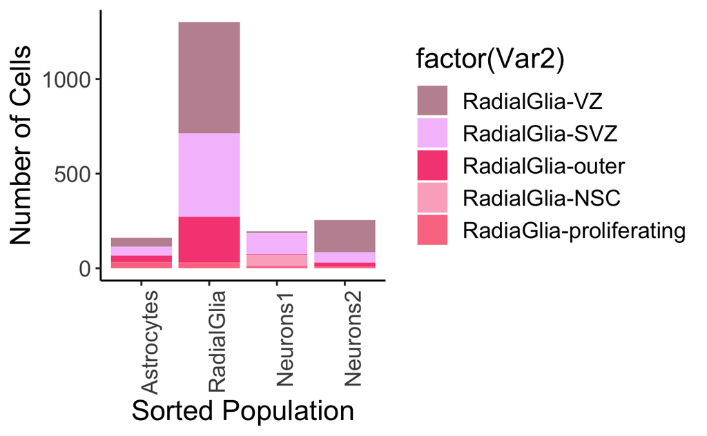

For Table S15

```r
# get all neuron subtypes
sample.lables <- as.data.frame(table(seu.sc$orig.ident, seu.sc$Subtypes))

s.table <- reshape(sample.lables, idvar = "Var2", timevar = "Var1", direction = "wide")

head(s.table)
```

|  | Var2 | Freq.Neurons1 | Freq.Neurons2 | Freq.Astrocytes | Freq.RadialGlia |
| --- | --- | --- | --- | --- | --- |
| 1 | Astrocytes-immature | 8 | 72 | 1535 | 175 |
| 5 | Neurons-Endocrine | 2 | 784 | 11 | 57 |
| 9 | RadialGlia-VZ | 10 | 172 | 48 | 587 |
| 13 | Neurons-Excitatory | 564 | 0 | 0 | 0 |
| 17 | Astrocytes-reactive | 0 | 5 | 747 | 207 |
| 21 | Neurons-GABAergic | 5 | 302 | 55 | 53 |

```r
write.csv(s.table, paste(output_path,"freq_subtypes_Feb7.csv",sep = ""))


# table of main cell types
sample.lables <- as.data.frame(table(seu.sc$orig.ident, seu.sc$Cell_Type2))

s.table <- reshape(sample.lables, idvar = "Var2", timevar = "Var1", direction = "wide")

head(s.table)
```

|  | Var2 | Freq.Neurons1 | Freq.Neurons2 | Freq.Astrocytes | Freq.RadialGlia |
| --- | --- | --- | --- | --- | --- |
| 1 | Astrocytes | 13 | 80 | 2606 | 383 |
| 5 | Neurons | 1153 | 1428 | 142 | 147 |
| 9 | RadialGlia | 196 | 256 | 161 | 1300 |
| 13 | DANeurons | 206 | 146 | 7 | 117 |
| 17 | Mix | 15 | 84 | 81 | 48 |
| 21 | NPC | 140 | 6 | 3 | 5 |

```r
write.csv(s.table, paste(output_path,"freq_MaintypeFreq_Feb8.csv",sep = ""))
```

Subtype markers

DotPlots of markers in cell type subsets

```r
# neuron subtype
n.markers <- c("ASCL1","CP","GRIA2","MGP","SPARCL1","TPH1","TFPI2","CD24")

DotPlot(neurons, features = n.markers) +
  theme(text = element_text(size=16, colour = "black"),axis.text.x = element_text(angle = 90))


# DA neuron subytype markers
da.markers <- c("RAB3B","TPBG","TTR","TH","SOX6","CALB1","SLC17A6")

DotPlot(neurons.da, features = da.markers) +
  theme(text = element_text(size=16, colour = "black"),axis.text.x = element_text(angle = 90))



# new markers
da1 <- c("RAB3B","SCG2","CALB1","RASGRP","STMN2","ADCYAP1","PTPRO")
da2 <- c("TPBG","PTGDS","CD9","DLK1","SPARC","RBP1","HES1")
da3 <- c("TTR","NEUROD1","NDUFA4","SYT1","SLC1A2","OLFM2","FAM19A4")
da1 <- c("RAB3B","SCG2","CALB1","RASGRP","ADCYAP1","PTPRO")
da2 <- c("TPBG","PTGDS","CD9","DLK1","SPARC","RBP1")
da3 <- c("NEUROD1","NDUFA4","SYT1","SLC1A2","OLFM2","FAM19A4")
da.markers <- c(da1,da2,da3)
DotPlot(neurons.da, features = da.markers) +
  theme(text = element_text(size=16, colour = "black"),axis.text.x = element_text(angle = 90))

pdf(paste(output_path,"Dotplot_DANeuSubMarkersJan25.pdf",sep = ""),width = 7, height = 4)
DotPlot(neurons.da, features = da.markers) +
  theme(text = element_text(size=16, colour = "black"),axis.text.x = element_text(angle = 90))
dev.off()


rg.markers <- c("CYP1B1","NEAT1","PTN","RPL41","TOP2A","VCAN","SOX2","SLIT2","HES1","VIM")

pdf(paste(output_path,"Dotplot_RGMarkersOct17.pdf",sep = ""),width = 7, height = 4)
DotPlot(rg, features = rg.markers) +
  theme(text = element_text(size=16, colour = "black"),axis.text.x = element_text(angle = 90))
dev.off()

# Apoe, Gfap, Aqp4 and Slc1a3
astro.markers <- c("COL3A1","FABP5","HPD","APOE","S100B","IGFBP2","DBI",
                   "PRSS56", "IGTP","LFIT3","LIGP1",
                   "COL1A2")

pdf(paste(output_path,"Dotplot_AstroMarkersOct17.pdf",sep = ""),width = 7, height = 4)
DotPlot(astro, features = astro.markers) +
  theme(text = element_text(size=16, colour = "black"),axis.text.x = element_text(angle = 90))
dev.off()
```

[output not shown]

Counts of DA neuron subtypes per subgroup - table

```r
# original clusters proportion of cell types in
library(reshape2)

pr.celltypes <- as.data.frame(table(seu.da$Subtypes,seu.da$orig.ident))
pr.celltypes <- reshape(pr.celltypes, idvar = "Var2", timevar = "Var1", direction = "wide")
pr.celltypes
```

|  | Var2 | Freq.Astrocytes-immature | Freq.Neurons-Endocrine | Freq.RadialGlia-VZ | Freq.Neurons-Excitatory | Freq.Astrocytes-reactive | Freq.Neurons-GABAergic | Freq.RadialGlia-SVZ | Freq.Neurons-Glutamatergic | Freq.Astrocytes-resting | Freq.Neurons-Mature | Freq.RadialGlia-outer | Freq.DANeurons-VTA | Freq.Neurons_stem_potential | Freq.Mix | Freq.NPC | Freq.Neurons-5HT | Freq.DANeurons-VM | Freq.DANeurons-SN | Freq.RadialGlia-NSC | Freq.RadiaGlia-proliferating |
| --- | --- | --- | --- | --- | --- | --- | --- | --- | --- | --- | --- | --- | --- | --- | --- | --- | --- | --- | --- | --- | --- |
| 1 | Neurons1 | 0 | 0 | 0 | 0 | 0 | 0 | 0 | 0 | 0 | 0 | 0 | 131 | 0 | 0 | 0 | 0 | 10 | 65 | 0 | 0 |
| 21 | Neurons2 | 0 | 0 | 0 | 0 | 0 | 0 | 0 | 0 | 0 | 0 | 0 | 76 | 0 | 0 | 0 | 0 | 50 | 20 | 0 | 0 |
| 41 | Astrocytes | 0 | 0 | 0 | 0 | 0 | 0 | 0 | 0 | 0 | 0 | 0 | 0 | 0 | 0 | 0 | 0 | 7 | 0 | 0 | 0 |
| 61 | RadialGlia | 0 | 0 | 0 | 0 | 0 | 0 | 0 | 0 | 0 | 0 | 0 | 52 | 0 | 0 | 0 | 0 | 46 | 19 | 0 | 0 |

```r
pr <- pr.celltypes %>% select(Var2,`Freq.DANeurons-VTA`,`Freq.DANeurons-VM`,`Freq.DANeurons-SN`)
pr
```

|  | Var2 | Freq.DANeurons-VTA | Freq.DANeurons-VM | Freq.DANeurons-SN |
| --- | --- | --- | --- | --- |
| 1 | Neurons1 | 131 | 10 | 65 |
| 21 | Neurons2 | 76 | 50 | 20 |
| 41 | Astrocytes | 0 | 7 | 0 |
| 61 | RadialGlia | 52 | 46 | 19 |

```r
pr <- t(pr)
pr
```

```
                   1          21         41
Var2               "Neurons1" "Neurons2" "Astrocytes"
Freq.DANeurons-VTA "131"      " 76"      "  0"
Freq.DANeurons-VM  "10"       "50"       " 7"
Freq.DANeurons-SN  "65"       "20"       " 0"
                   61
Var2               "RadialGlia"
Freq.DANeurons-VTA " 52"
Freq.DANeurons-VM  "46"
Freq.DANeurons-SN  "19"
```

Proportion of cell types tests Compare FACS Neurons1 to Neurons2

Check the proportions of subtypes of DA neurons Check proportions of all main cell types

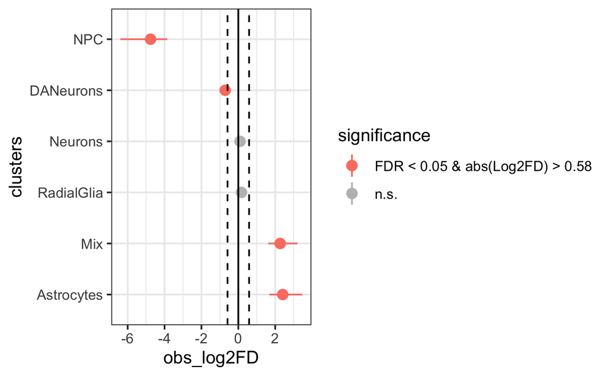

```r
library("scProportionTest")

prop_test <- sc_utils(seu.sc)

prop_test <- permutation_test(
    prop_test, cluster_identity = "Cell_Type2",
    sample_1 = "Neurons1", sample_2 = "Neurons2",
    sample_identity = "orig.ident"
)

permutation_plot(prop_test)
```

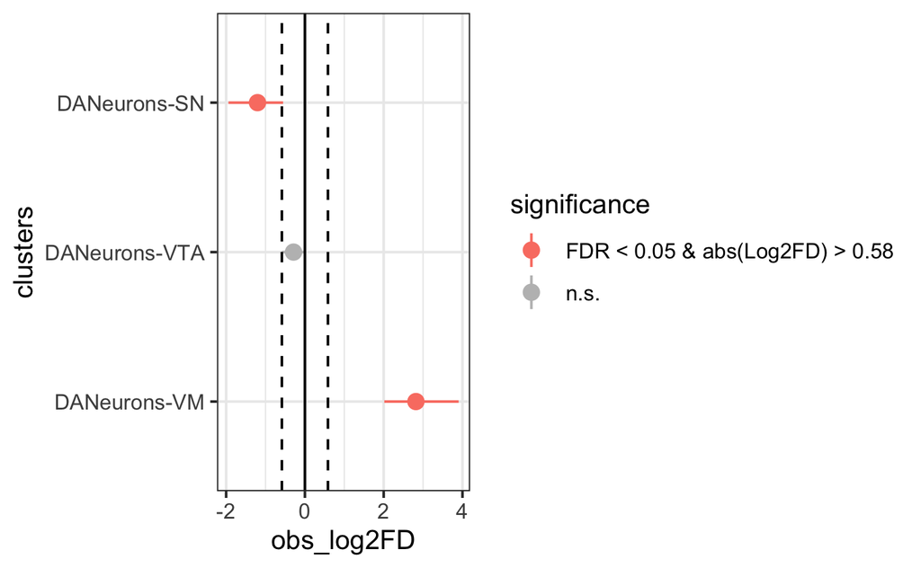

```r
prop_test <- sc_utils(seu.da)

prop_test <- permutation_test(
    prop_test, cluster_identity = "Subtypes",
    sample_1 = "Neurons1", sample_2 = "Neurons2",
    sample_identity = "orig.ident"
)

permutation_plot(prop_test)
```

```r
NA
NA
```